# Estadística Multidimensional — Análisis Exploratorio Integral

Dataset: Comportamiento Crediticio y Riesgo Financiero (Semanas 1 a 3)

Estadística Multidimensional

05/09/2026

```r
knitr::opts_chunk$set(
  echo = TRUE,
  comment = "#>",
  fig.width = 9,
  fig.height = 6,
  fig.align = "center",
  warning = FALSE,
  message = FALSE
)
```

# 1 Contexto y Objetivos del Análisis

Este documento desarrolla la exploración multidimensional del conjunto de datos `bronze/synthetic_credit_card_customer_behavior_dataset.csv`. Integra de manera secuencial y exhaustiva los métodos, herramientas conceptuales y requerimientos desarrollados a lo largo de las **Semanas 1 a 3**:

- **Semana 1 (S01):** La matriz de datos $\mathbf{X}$, dimensiones ($n \times p$), clasificación de variables, medidas univariadas y bivariadas, y matrices de correlación y dispersión (`pairs`).
- **Semana 2 (S02):** Flujo de importación reproducible (`readLines`), auditoría de integridad, diagnóstico multivariante de datos faltantes (`complete.cases` vs `is.na`), verificación de duplicados e inconsistencias numéricas.
- **Semana 3 (S03):** Visualización en el espacio, impacto del número de clases en histogramas (`breaks` y regla de Sturges), análisis de dispersión y atípicos univariados con boxplots y la regla de Tukey ($1.5 \cdot RIC$), boxplots multivariados estandarizados (`scale`), y la demostración formal y gráfica del **“punto imposible”** (outlier multivariante no detectable univariadamente).

# 2 Módulo 1: Inspección Previa e Importación Reproducible (S02)

## 2.1 Mirar antes de leer (`readLines`)

Antes de cargar cualquier archivo en memoria, es una buena práctica de reproducibilidad inspeccionar sus primeras líneas en crudo para verificar delimitadores de columnas, separadores decimales y presencia de encabezados.

```r
ruta_credit <- "bronze/synthetic_credit_card_customer_behavior_dataset.csv"
lineas_muestra <- readLines(ruta_credit, n = 4)
lineas_muestra
```

```
#> [1] "Customer_ID,Age,Gender,Annual_Income,Occupation,Card_Type,Credit_Limit,Card_Age_Months,Monthly_Spending,Monthly_Transactions,Avg_Transaction_Value,Online_Shopping_Spending,Grocery_Spending,Fuel_Spending,Dining_Spending,Travel_Spending,Entertainment_Spending,Utility_Bill_Spending,Outstanding_…
#> [2] "CC100000,33,M,787406,Self-Employed,Silver,220000.0,20,36733.49,83,427.21,1317.13,9400.14,4339.48,10476.83,3092.29,2275.83,5831.79,149956.45,178851.64,82271.75,0.46,0.7,14839.84,2,0,1081,210,23,492"
#> [3] "CC100001,58,M,598084,Retired,Basic,112000.0,101,30212.78,72,399.89,3892.84,6134.61,3442.74,3869.99,2020.56,2639.89,8212.15,84159.21,110031.93,104530.33,0.95,0.76,0.0,2,0,606,163,22,607"
#> [4] "CC100002,40,F,1710737,Private Employee,Platinum,928000.0,12,115895.71,142,837.85,13547.09,40293.0,11946.73,6272.35,1440.7,8502.96,33892.88,342440.99,424486.51,148570.28,0.35,0.38,73713.82,2,3,6857,0,48,549"
```

**Diagnóstico preliminar:** * **Separador de columnas:** Coma (`,`). * **Separador decimal:** Punto (`.`). * **Encabezado:** Presente en la primera fila con nombres descriptivos de variables. * **Estrategia de lectura:** Corresponde utilizar `read.csv()` con `header = TRUE`, `sep = ","`, `dec = "."` y `stringsAsFactors = FALSE`.

## 2.2 Importación explícita

```r
credit <- read.csv(
  file = ruta_credit,
  header = TRUE,
  sep = ",",
  dec = ".",
  stringsAsFactors = FALSE
)
```

## 2.3 Dimensiones de la matriz de datos ($\mathbf{X} \in \mathbb{R}^{n \times p}$)

```r
dim_matriz <- dim(credit)
dim_matriz
```

```
#> [1] 50000    30
```

La matriz de datos contiene: * $n = 50000$ observaciones (clientes simulados / filas). * $p = 30$ variables medidas (columnas).

## 2.4 Estructura y clasificación de variables (S01 & Everitt & Hothorn)

```r
str(credit)
```

```
#> 'data.frame':    50000 obs. of  30 variables:
#>  $ Customer_ID               : chr  "CC100000" "CC100001" "CC100002" "CC100003" ...
#>  $ Age                       : int  33 58 40 42 19 19 18 51 35 38 ...
#>  $ Gender                    : chr  "M" "M" "F" "M" ...
#>  $ Annual_Income             : int  787406 598084 1710737 712664 1504662 1554404 1127008 546395 577570 774834 ...
#>  $ Occupation                : chr  "Self-Employed" "Retired" "Private Employee" "Private Employee" ...
#>  $ Card_Type                 : chr  "Silver" "Basic" "Platinum" "Silver" ...
#>  $ Credit_Limit              : num  220000 112000 928000 211000 572000 563000 439000 91000 94000 140000 ...
#>  $ Card_Age_Months           : int  20 101 12 54 44 59 38 44 74 81 ...
#>  $ Monthly_Spending          : num  36733 30213 115896 21804 91039 ...
#>  $ Monthly_Transactions      : int  83 72 142 64 67 66 49 66 46 70 ...
#>  $ Avg_Transaction_Value     : num  427 400 838 357 1367 ...
#>  $ Online_Shopping_Spending  : num  1317 3893 13547 7583 19794 ...
#>  $ Grocery_Spending          : num  9400 6135 40293 5597 9898 ...
#>  $ Fuel_Spending             : num  4339 3443 11947 1207 13912 ...
```

[output cut: 16 more lines]

En la taxonomía del análisis multivariante (Everitt & Hothorn, Cap. 1), las $p = 30$ variables se clasifican en:

1. **Variables Cuantitativas / Numéricas (26):**
   - *Continuas de escala monetaria y gastos:* `Annual_Income`, `Monthly_Spending`, `Avg_Transaction_Value`, `Online_Shopping_Spending`, `Grocery_Spending`, `Fuel_Spending`, `Dining_Spending`, `Travel_Spending`, `Entertainment_Spending`, `Utility_Bill_Spending`, `Cash_Advance_Amount`, `Outstanding_Balance`, `Statement_Balance`, `Payment_Amount`, `Credit_Limit`.
   - *Continuas / Ratios e Índices:* `Payment_Ratio`, `Credit_Utilization`.
   - *Discretas / Conteos y Puntuaciones:* `Age`, `Card_Age_Months`, `Monthly_Transactions`, `EMI_Count`, `International_Transactions`, `Reward_Points_Earned`, `Reward_Points_Redeemed`, `Mobile_App_Login`, `Credit_Score`.
2. **Variables Cualitativas / Categóricas (4):**
   - *Nominales:* `Customer_ID` (identificador único), `Gender`, `Occupation`, `Card_Type`.

# 3 Módulo 2: Auditoría y Diagnóstico de Calidad de la Matriz (S02)

## 3.1 Diagnóstico multivariante de datos faltantes

Un concepto central de la estadística multivariante es que un dato faltante no es solo una celda vacía: al descartar una fila incompleta en un análisis conjunto, se pierde el vector completo $\mathbf{x}_i \in \mathbb{R}^p$.

```r
total_celdas <- prod(dim(credit))
celdas_na <- sum(is.na(credit))
pct_celdas_na <- (celdas_na / total_celdas) * 100

filas_completas <- sum(complete.cases(credit))
pct_filas_completas <- (filas_completas / nrow(credit)) * 100

# Conteo por columna
faltantes_por_col <- colSums(is.na(credit))
faltantes_por_col[faltantes_por_col > 0]
```

```
#> named numeric(0)
```

- **Total de celdas en la matriz:** 1,500,000
- **Celdas vacías (`NA`):** 0 (0.00%)
- **Filas completas (`complete.cases`):** 50,000 (100.00%)

> **Conclusión:** La matriz $\mathbf{X}$ está $100\%$ completa. No se presentan discrepancias entre estrategias de casos completos (`use = "complete.obs"`) y completitud por pares (`use = "pairwise.complete.obs"`).

## 3.2 Verificación de duplicados e identificadores

```r
n_duplicados_filas <- sum(duplicated(credit))
n_duplicados_id <- sum(duplicated(credit$Customer_ID))
```

- **Filas exactamente duplicadas:** 0
- **Identificadores de cliente repetidos:** 0

## 3.3 Resumen univariado global y revisión de rangos (`summary`)

```r
summary(credit)
```

```
#>     Customer_ID         Age              Gender      Annual_Income
#>  Length   :50000   Min.   :18.00   Length   :50000   Min.   : 100050
#>  N.unique :50000   1st Qu.:27.00   N.unique :    2   1st Qu.: 657774
#>  N.blank  :    0   Median :34.00   N.blank  :    0   Median :1127630
#>  Min.nchar:    8   Mean   :36.08   Min.nchar:    1   Mean   :1479318
#>  Max.nchar:    8   3rd Qu.:44.00   Max.nchar:    1   3rd Qu.:1663624
#>                    Max.   :70.00                     Max.   :7995831
#>      Occupation        Card_Type      Credit_Limit     Card_Age_Months
#>  Length   :50000   Length   :50000   Min.   :  16000   Min.   :  1.00
#>  N.unique :    6   N.unique :    5   1st Qu.: 157000   1st Qu.: 31.00
#>  N.blank  :    0   N.blank  :    0   Median : 396000   Median : 48.00
#>  Min.nchar:    7   Min.nchar:    4   Mean   : 709677   Mean   : 53.63
#>  Max.nchar:   19   Max.nchar:    9   3rd Qu.: 779000   3rd Qu.: 70.00
#>                                      Max.   :6591000   Max.   :240.00
#>  Monthly_Spending Monthly_Transactions Avg_Transaction_Value
#>  Min.   :  2236   Min.   : 15.00       Min.   :   57.76
#>  1st Qu.: 26646   1st Qu.: 49.00       1st Qu.:  448.38
#>  Median : 50022   Median : 76.00       Median :  617.16
#>  Mean   : 73872   Mean   : 83.04       Mean   :  835.99
#>  3rd Qu.: 83030   3rd Qu.:108.00       3rd Qu.:  901.25
#>  Max.   :691688   Max.   :179.00       Max.   :10463.06
#>  Online_Shopping_Spending Grocery_Spending    Fuel_Spending
#>  Min.   :    13.85        Min.   :    83.81   Min.   :    10.95
#>  1st Qu.:  2800.70        1st Qu.:  5176.97   1st Qu.:  2432.16
#>  Median :  6163.21        Median : 10651.41   Median :  5466.36
#>  Mean   : 11238.28        Mean   : 17794.28   Mean   : 10212.73
#>  3rd Qu.: 12820.20        3rd Qu.: 20419.57   3rd Qu.: 11560.76
#>  Max.   :258176.00        Max.   :352971.49   Max.   :235635.14
#>  Dining_Spending     Travel_Spending     Entertainment_Spending
#>  Min.   :     5.77   Min.   :     0.26   Min.   :     1.37
#>  1st Qu.:  2089.51   1st Qu.:  1077.05   1st Qu.:  1570.09
#>  Median :  4847.46   Median :  2883.43   Median :  3829.70
#>  Mean   :  9090.10   Mean   :  6141.73   Mean   :  7648.22
#>  3rd Qu.: 10381.72   3rd Qu.:  6862.71   3rd Qu.:  8612.79
#>  Max.   :227439.65   Max.   :213127.41   Max.   :216730.17
#>  Utility_Bill_Spending Outstanding_Balance Statement_Balance
#>  Min.   :    19.75     Min.   :   1600     Min.   :   4161
#>  1st Qu.:  2978.53     1st Qu.:  55641     1st Qu.:  82472
#>  Median :  6574.18     Median : 145306     Median : 192358
#>  Mean   : 11746.45     Mean   : 303420     Mean   : 366172
```

[output cut: 8 more lines]

```
#>  Max.   :5980747.0   Max.   :1.0000   Max.   :0.9500     Max.   :1212849
#>    EMI_Count     International_Transactions Reward_Points_Earned
#>  Min.   :0.000   Min.   : 0.00              Min.   :   44
#>  1st Qu.:1.000   1st Qu.: 0.00              1st Qu.:  720
#>  Median :2.000   Median : 0.00              Median : 1833
#>  Mean   :2.447   Mean   : 1.53              Mean   : 3891
#>  3rd Qu.:4.000   3rd Qu.: 2.00              3rd Qu.: 3767
#>  Max.   :6.000   Max.   :14.00              Max.   :56341
#>  Reward_Points_Redeemed Mobile_App_Login  Credit_Score
#>  Min.   :    0          Min.   : 2.00    Min.   :367
#>  1st Qu.:    0          1st Qu.:20.00    1st Qu.:585
#>  Median :  135          Median :31.00    Median :638
#>  Mean   :  872          Mean   :33.16    Mean   :629
#>  3rd Qu.:  731          3rd Qu.:44.00    3rd Qu.:681
#>  Max.   :44818          Max.   :71.00    Max.   :792
```

## 3.4 Tablas de frecuencia para variables categóricas

```r
table(credit$Gender, useNA = "always")
```

```
#>
#>     F     M  <NA>
#> 22392 27608     0
```

```r
table(credit$Card_Type, useNA = "always")
```

```
#>
#>     Basic      Gold  Platinum Signature    Silver      <NA>
#>     10261     16895      8284      2504     12056         0
```

```r
table(credit$Occupation, useNA = "always")
```

```
#>
#>      Business Owner Government Employee    Private Employee             Retired
#>                6038                7595               20960                4047
#>       Self-Employed             Student                <NA>
#>                7440                3920                   0
```

# 4 Módulo 3: Análisis Univariado y la Decisión Gráfica del Histograma (S01 & S03)

## 4.1 Estadísticos descriptivos univariados

```r
# Selección de la variable Credit_Score para estudio univariado
score <- credit$Credit_Score

media_cs <- mean(score)
sd_cs <- sd(score)
mediana_cs <- median(score)
min_cs <- min(score)
max_cs <- max(score)

c(Media = media_cs, Desv_Std = sd_cs, Mediana = mediana_cs, Min = min_cs, Max = max_cs)
```

```
#>     Media  Desv_Std   Mediana       Min       Max
#> 628.98458  68.44425 638.00000 367.00000 792.00000
```

```r
ceiling(log2(nrow(credit))) + 1
```

```
#> [1] 17
```

## 4.2 El histograma y el efecto del número de cortes (`breaks`) (S03 - Sesión 4)

El histograma es una estimación no paramétrica de la función de densidad subyacente. La elección de la cantidad de intervalos (`breaks` o ancho de clase $h$) altera profundamente la percepción de la distribución:

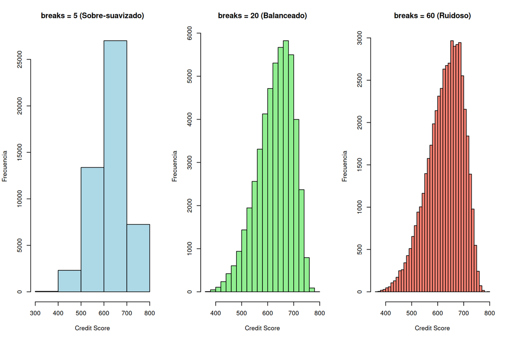

```r
par(mfrow = c(1, 3))

# Histograma con muy pocos cortes (sobre-suavizado / underfitting)
hist(score, breaks = 5, col = "lightblue", border = "black",
     main = "breaks = 5 (Sobre-suavizado)",
     xlab = "Credit Score", ylab = "Frecuencia")

# Histograma con cortes intermedios
hist(score, breaks = 20, col = "lightgreen", border = "black",
     main = "breaks = 20 (Balanceado)",
     xlab = "Credit Score", ylab = "Frecuencia")

# Histograma con demasiados cortes (ruidoso / overfitting)
hist(score, breaks = 60, col = "salmon", border = "black",
     main = "breaks = 60 (Ruidoso)",
     xlab = "Credit Score", ylab = "Frecuencia")
```

```r
par(mfrow = c(1, 1))
```

## 4.3 Histogramas de todas las variables numéricas

Para no repetir el mismo texto en cada gráfica, definimos primero qué mide cada variable y por qué su distribución toma la forma que toma. Estos textos se imprimen automáticamente debajo de cada gráfico en los tres módulos siguientes (histogramas, boxplots y densidad).

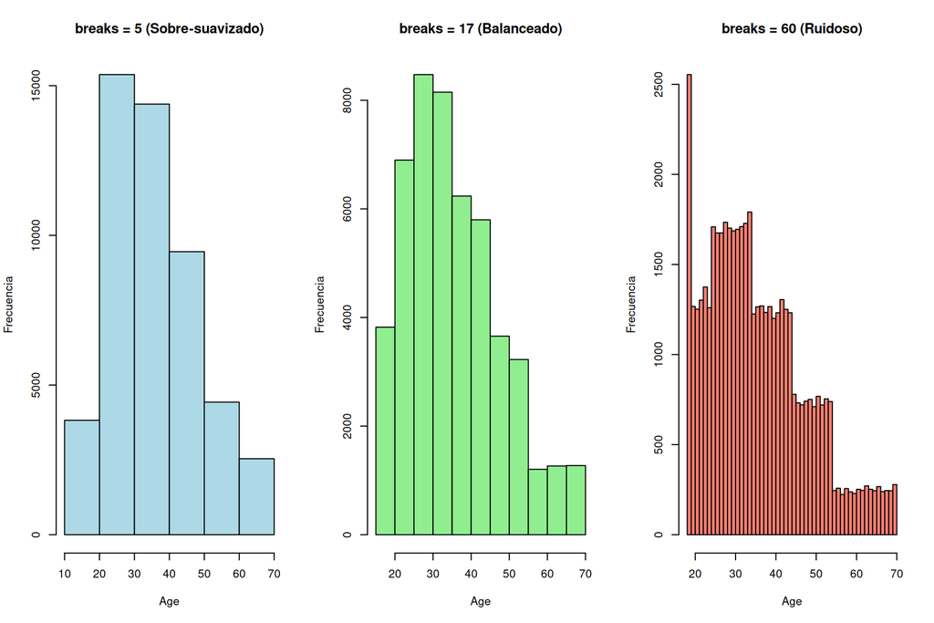

```r
numeric_cols <- names(credit)[sapply(credit, is.numeric)]

for (col_name in numeric_cols) {
  # Get the vector for the current numeric column
  current_var <- credit[[col_name]]

  # Calculate Sturges' breaks for the current variable
  k_sturges <- nclass.Sturges(current_var)

  # Set up the plotting area for three histograms
  par(mfrow = c(1, 3))

  # Histogram with very few breaks (under-smoothed / underfitting)
  hist(current_var, breaks = 5, col = "lightblue", border = "black",
       main = paste("breaks = 5 (Sobre-suavizado)"),
       xlab = col_name, ylab = "Frecuencia")

  # Histogram with Sturges' breaks (balanced)
  hist(current_var, breaks = k_sturges, col = "lightgreen", border = "black",
       main = paste("breaks =", k_sturges, "(Balanceado)"),
       xlab = col_name, ylab = "Frecuencia")

  # Histogram with too many breaks (noisy / overfitting)
  hist(current_var, breaks = 60, col = "salmon", border = "black",
       main = paste("breaks = 60 (Ruidoso)"),
       xlab = col_name, ylab = "Frecuencia")

  # Reset plotting area
  par(mfrow = c(1, 1))

  # Análisis corto de la variable y de la forma de su histograma
  cat(parrafo(col_name, "hist"))
}
```

[output not shown]

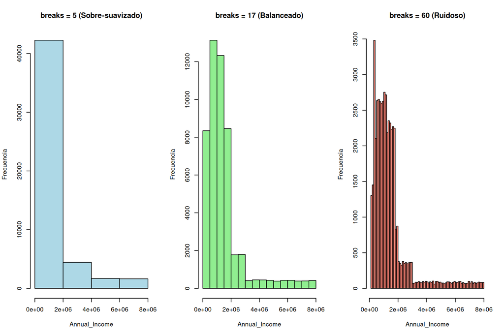

**Annual_Income** mide el ingreso anual declarado por el cliente. La cola larga hacia la derecha es lo esperable en cualquier variable de ingreso: la mayoría gana alrededor de la mediana y unos pocos ganan varias veces más, lo que empuja la media muy por encima de la mediana. Por eso la versión con `breaks = 5` aplana la forma y esconde el detalle, la de `breaks = 60` la fragmenta en picos que son ruido muestral, y la de Sturges es la que la muestra sin deformarla.

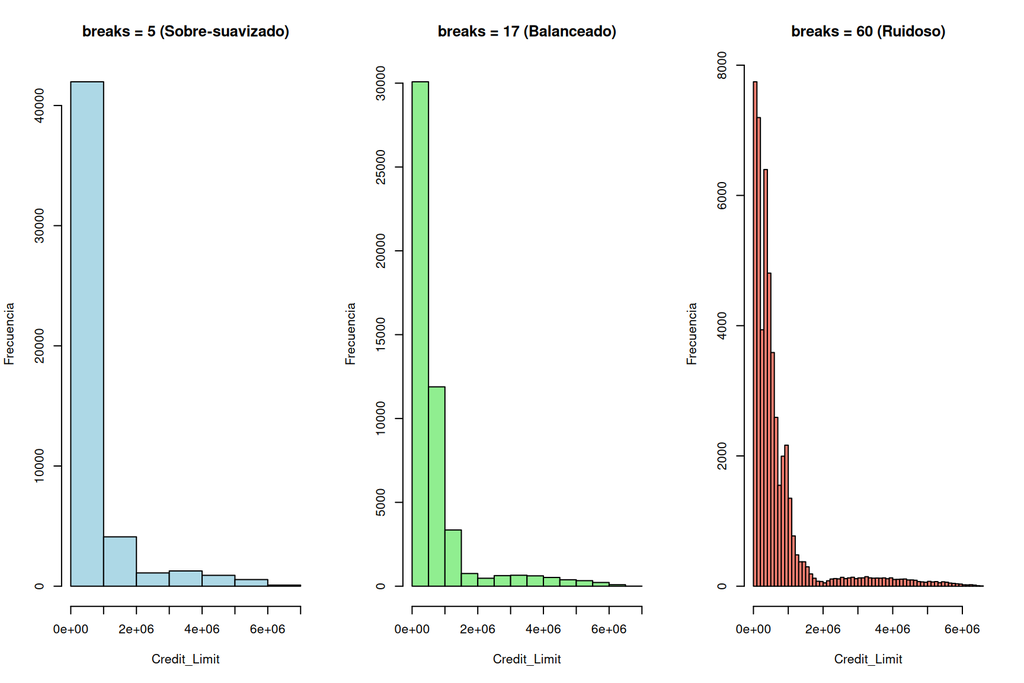

**Credit_Limit** mide el cupo total aprobado en la tarjeta. El cupo se asigna en función del ingreso, así que hereda la misma cola derecha; además solo toma valores redondeados (múltiplos de mil), por eso el histograma se ve escalonado y no continuo. Por eso la versión con `breaks = 5` aplana la forma y esconde el detalle, la de `breaks = 60` la fragmenta en picos que son ruido muestral, y la de Sturges es la que la muestra sin deformarla.

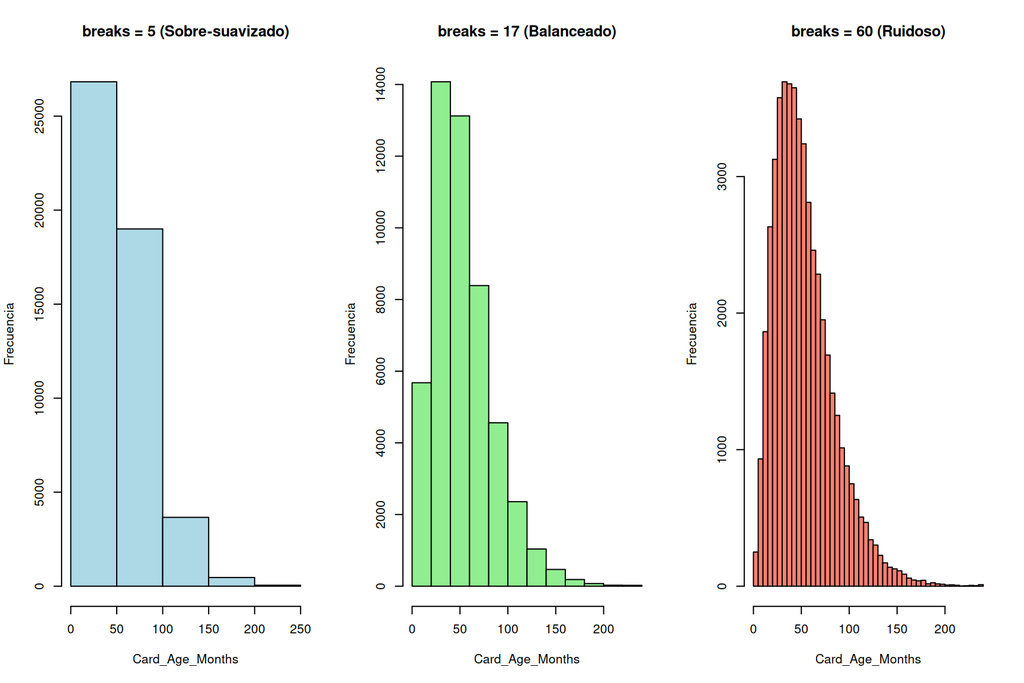

**Card_Age_Months** mide la antigüedad de la tarjeta en meses. Hay más tarjetas nuevas que antiguas, así que la masa se acumula en los primeros años y decae hacia los 240 meses: es el perfil de una cartera que sigue creciendo y captando clientes. Por eso la versión con `breaks = 5` aplana la forma y esconde el detalle, la de `breaks = 60` la fragmenta en picos que son ruido muestral, y la de Sturges es la que la muestra sin deformarla.

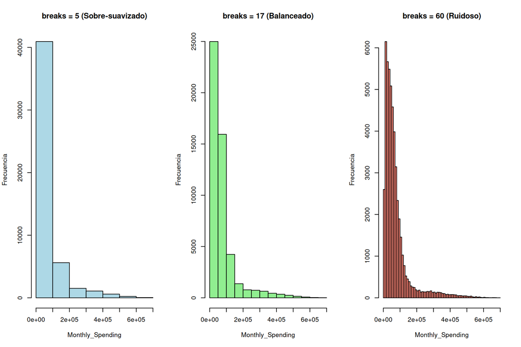

**Monthly_Spending** mide el gasto mensual total, que es la suma de las siete categorías de consumo. Al ser la suma de siete categorías que ya vienen sesgadas a la derecha, acumula todas esas colas: la mayoría gasta cerca de la mediana y un grupo pequeño gasta un orden de magnitud más. Por eso la versión con `breaks = 5` aplana la forma y esconde el detalle, la de `breaks = 60` la fragmenta en picos que son ruido muestral, y la de Sturges es la que la muestra sin deformarla.

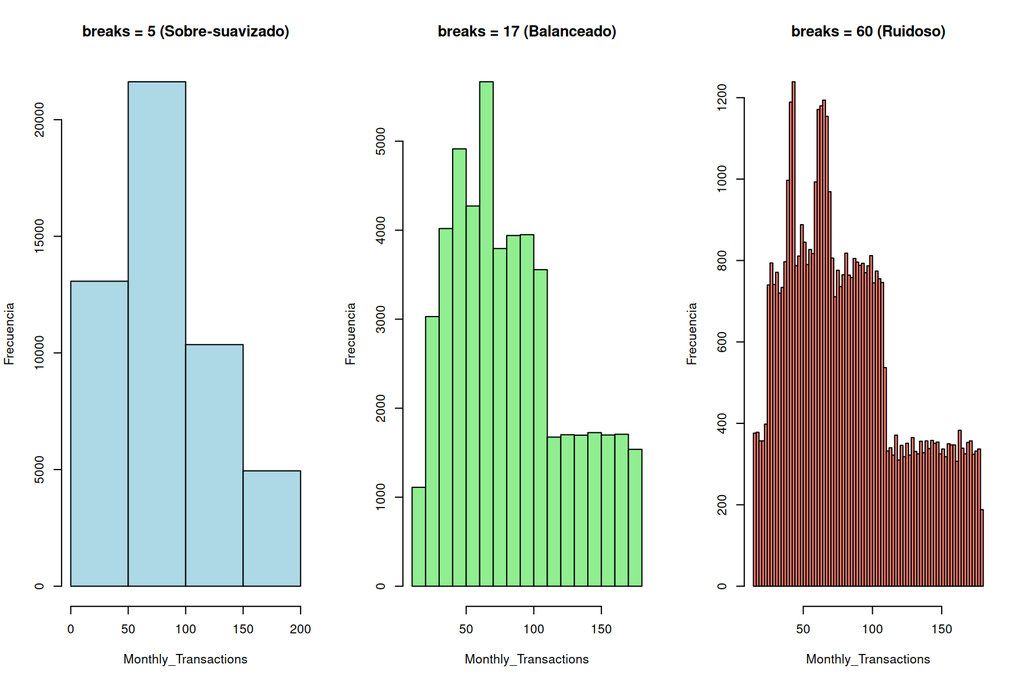

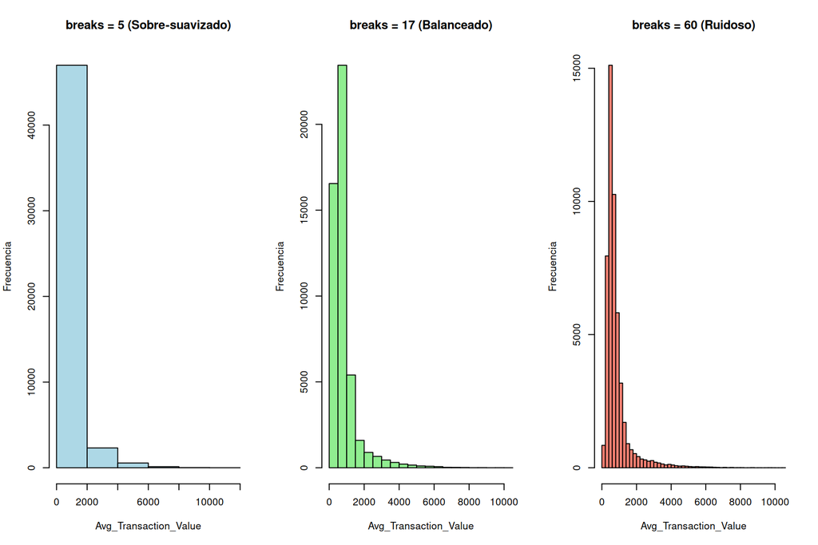

**Avg_Transaction_Value** mide el ticket promedio, es decir el gasto mensual dividido entre el número de transacciones. Es un cociente entre dos variables, y como el numerador tiene cola derecha y el denominador está acotado, el resultado queda fuertemente sesgado: dominan los tickets pequeños del día a día y unos pocos compradores de tickets altos estiran la cola. Por eso la versión con `breaks = 5` aplana la forma y esconde el detalle, la de `breaks = 60` la fragmenta en picos que son ruido muestral, y la de Sturges es la que la muestra sin deformarla.

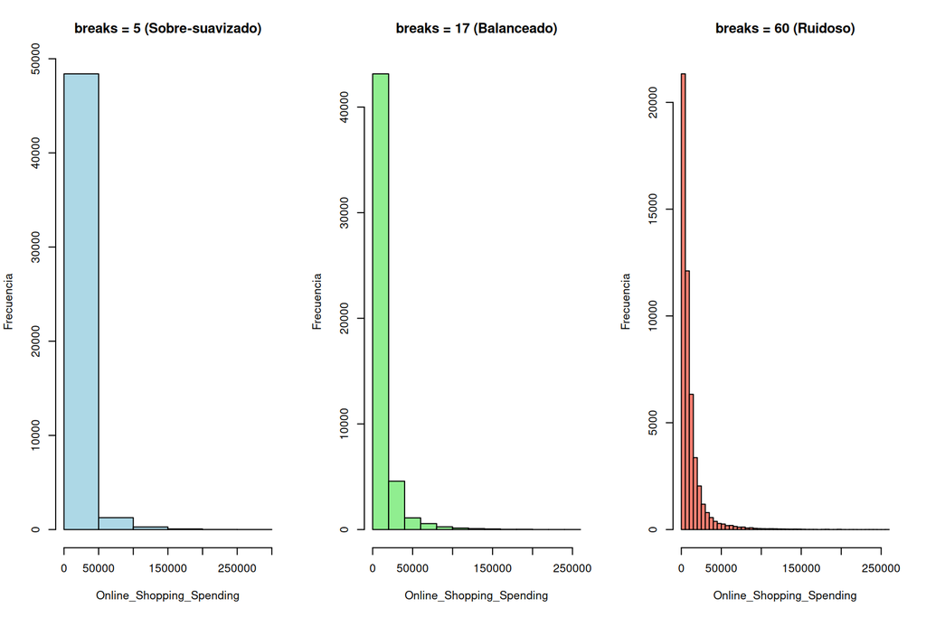

**Online_Shopping_Spending** mide el gasto mensual en compras por internet. Como todo gasto por categoría, la mayoría de clientes gasta poco y unos pocos gastan mucho, lo que produce el pico pegado al origen y la cola larga hacia la derecha. Por eso la versión con `breaks = 5` aplana la forma y esconde el detalle, la de `breaks = 60` la fragmenta en picos que son ruido muestral, y la de Sturges es la que la muestra sin deformarla.

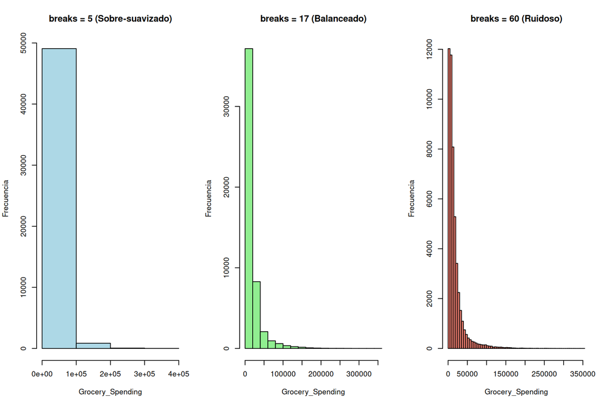

**Grocery_Spending** mide el gasto mensual en supermercado. Es la categoría con la mediana más alta de todas: el mercado es un gasto recurrente que casi todos hacen, por eso el pico está más desplazado del origen que en las demás categorías, aunque conserva la cola derecha. Por eso la versión con `breaks = 5` aplana la forma y esconde el detalle, la de `breaks = 60` la fragmenta en picos que son ruido muestral, y la de Sturges es la que la muestra sin deformarla.

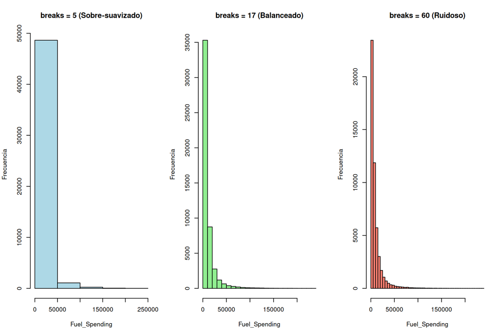

**Fuel_Spending** mide el gasto mensual en combustible. El gasto en combustible depende de si el cliente tiene vehículo y cuánto se desplaza, así que convive un grupo grande de gasto bajo con una minoría de gasto alto que alarga la cola. Por eso la versión con `breaks = 5` aplana la forma y esconde el detalle, la de `breaks = 60` la fragmenta en picos que son ruido muestral, y la de Sturges es la que la muestra sin deformarla.

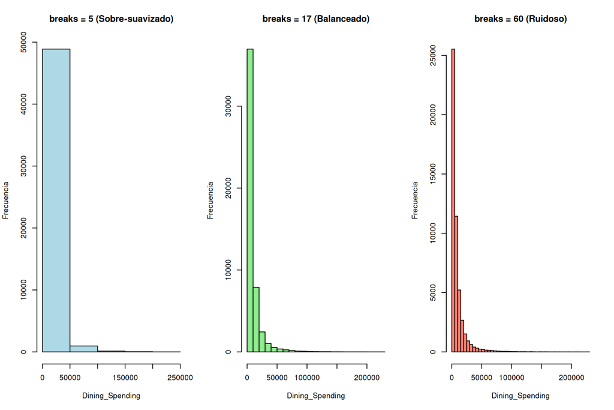

**Dining_Spending** mide el gasto mensual en restaurantes. Comer fuera es un gasto discrecional: la mayoría lo hace de forma moderada y una minoría concentra montos muy altos, de ahí el sesgo pronunciado a la derecha. Por eso la versión con `breaks = 5` aplana la forma y esconde el detalle, la de `breaks = 60` la fragmenta en picos que son ruido muestral, y la de Sturges es la que la muestra sin deformarla.

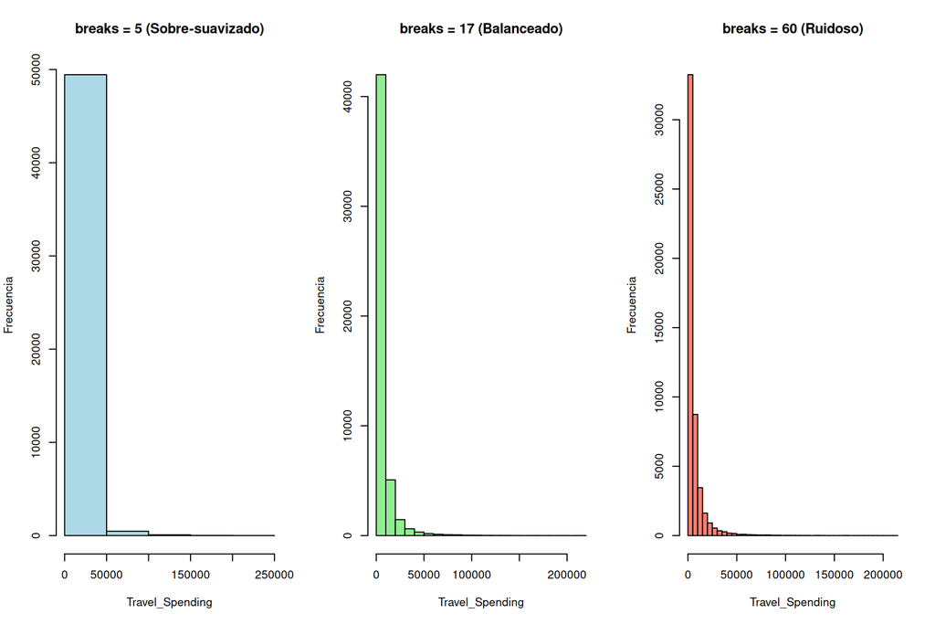

**Travel_Spending** mide el gasto mensual en viajes. Es el gasto más esporádico de todos (la mediana es la más baja de las categorías): la mayoría viaja poco o nada en el mes, y los pocos que viajan lo hacen con montos grandes, lo que produce la cola más larga del grupo. Por eso la versión con `breaks = 5` aplana la forma y esconde el detalle, la de `breaks = 60` la fragmenta en picos que son ruido muestral, y la de Sturges es la que la muestra sin deformarla.

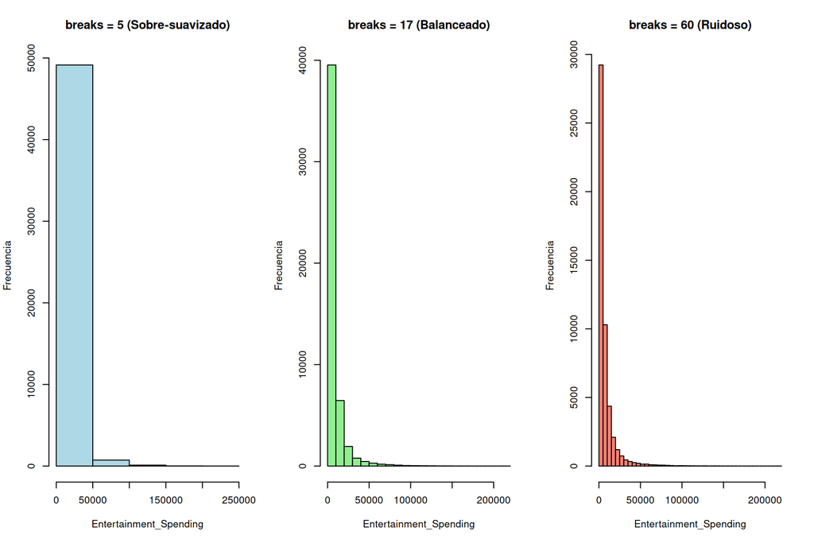

**Entertainment_Spending** mide el gasto mensual en entretenimiento. Gasto discrecional y ocasional: se concentra en montos bajos con una cola derecha marcada correspondiente a quienes consumen ocio de forma intensiva. Por eso la versión con `breaks = 5` aplana la forma y esconde el detalle, la de `breaks = 60` la fragmenta en picos que son ruido muestral, y la de Sturges es la que la muestra sin deformarla.

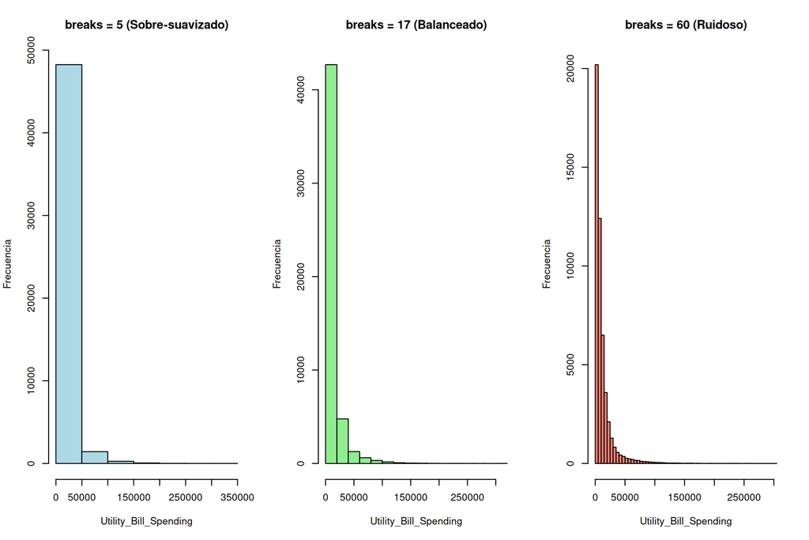

**Utility_Bill_Spending** mide el gasto mensual en servicios públicos pagados con la tarjeta. Domiciliar los servicios públicos en la tarjeta es una práctica frecuente pero de monto acotado, así que la masa está en valores bajos y la cola derecha viene de hogares con facturas altas. Por eso la versión con `breaks = 5` aplana la forma y esconde el detalle, la de `breaks = 60` la fragmenta en picos que son ruido muestral, y la de Sturges es la que la muestra sin deformarla.

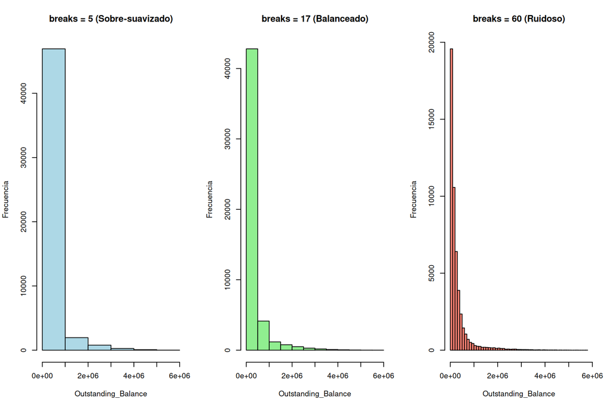

**Outstanding_Balance** mide el saldo que el cliente aún debe. La deuda pendiente sigue la misma lógica del gasto y del cupo: casi todos deben montos moderados y unos pocos arrastran saldos muy grandes, lo que estira la cola derecha. Por eso la versión con `breaks = 5` aplana la forma y esconde el detalle, la de `breaks = 60` la fragmenta en picos que son ruido muestral, y la de Sturges es la que la muestra sin deformarla.

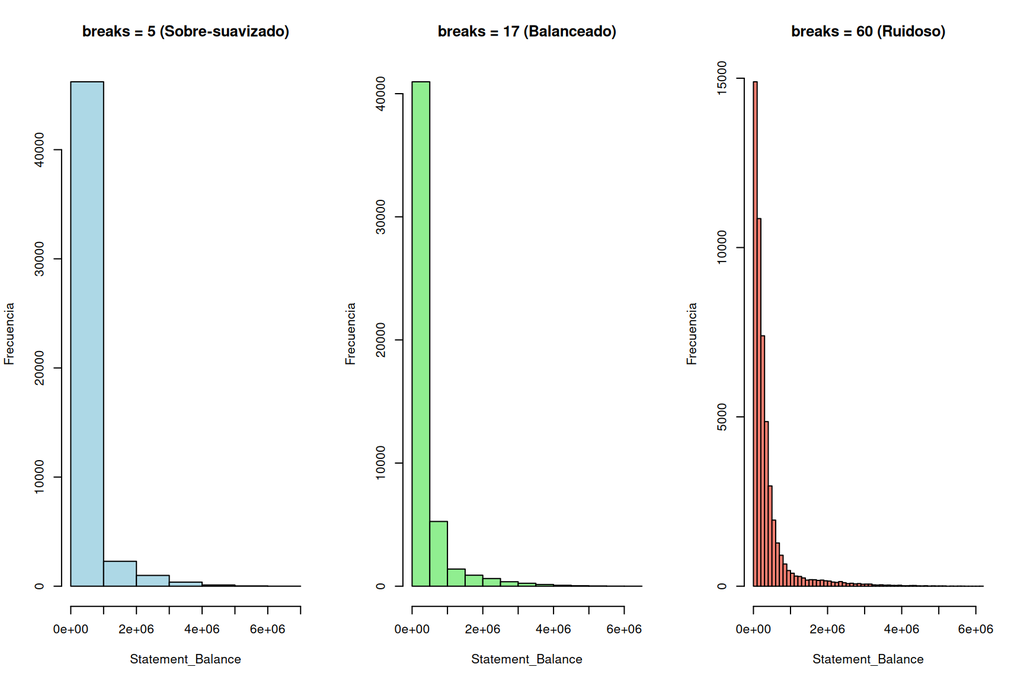

**Statement_Balance** mide el saldo facturado en el último corte del extracto. Es prácticamente la misma magnitud que el saldo pendiente medida en el corte de facturación, por eso su forma es casi idéntica a la de aquella variable. Por eso la versión con `breaks = 5` aplana la forma y esconde el detalle, la de `breaks = 60` la fragmenta en picos que son ruido muestral, y la de Sturges es la que la muestra sin deformarla.

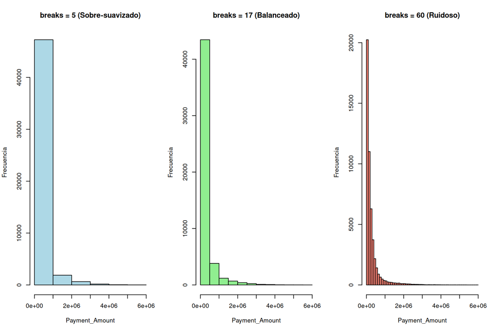

**Payment_Amount** mide el monto que el cliente pagó en el mes. El pago es proporcional a lo facturado, así que reproduce la forma sesgada del saldo: pagos moderados en la mayoría y pagos muy grandes en la minoría con saldos altos. Por eso la versión con `breaks = 5` aplana la forma y esconde el detalle, la de `breaks = 60` la fragmenta en picos que son ruido muestral, y la de Sturges es la que la muestra sin deformarla.

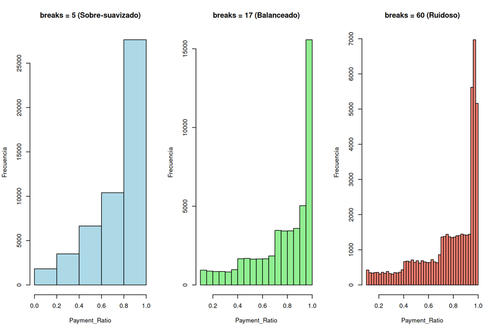

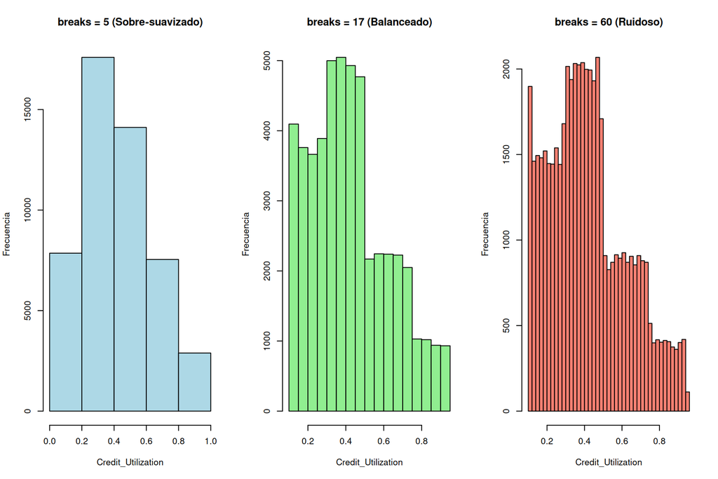

**Credit_Utilization** mide la proporción del cupo que el cliente tiene usada. Es una proporción acotada entre 0 y 1 por construcción, y las políticas de cupo evitan que los clientes lleguen al tope, por eso la forma es compacta, sin colas y sin ningún dato fuera de los bigotes. Por eso la versión con `breaks = 5` aplana la forma y esconde el detalle, la de `breaks = 60` la fragmenta en picos que son ruido muestral, y la de Sturges es la que la muestra sin deformarla.

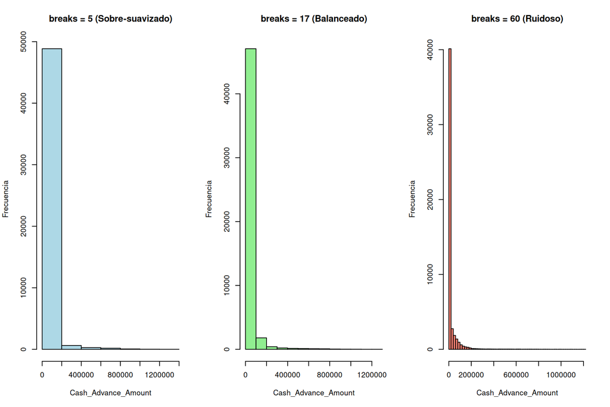

**Cash_Advance_Amount** mide el monto retirado como avance en efectivo. Más de la mitad de los clientes nunca hace avances, así que la distribución tiene un bloque enorme en cero y una cola larga formada por la minoría que sí los usa: es una variable inflada en cero, no una distribución continua clásica. Por eso la versión con `breaks = 5` aplana la forma y esconde el detalle, la de `breaks = 60` la fragmenta en picos que son ruido muestral, y la de Sturges es la que la muestra sin deformarla.

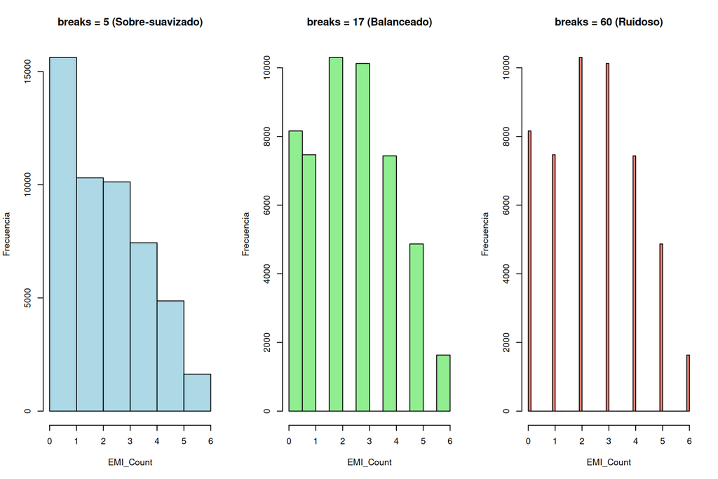

**EMI_Count** mide el número de compras diferidas a cuotas que el cliente tiene vigentes. Solo toma siete valores enteros (de 0 a 6 cuotas vigentes), por eso el histograma se ve como barras separadas y no como una curva: es un conteo discreto de rango muy corto. Por eso la versión con `breaks = 5` aplana la forma y esconde el detalle, la de `breaks = 60` la fragmenta en picos que son ruido muestral, y la de Sturges es la que la muestra sin deformarla.

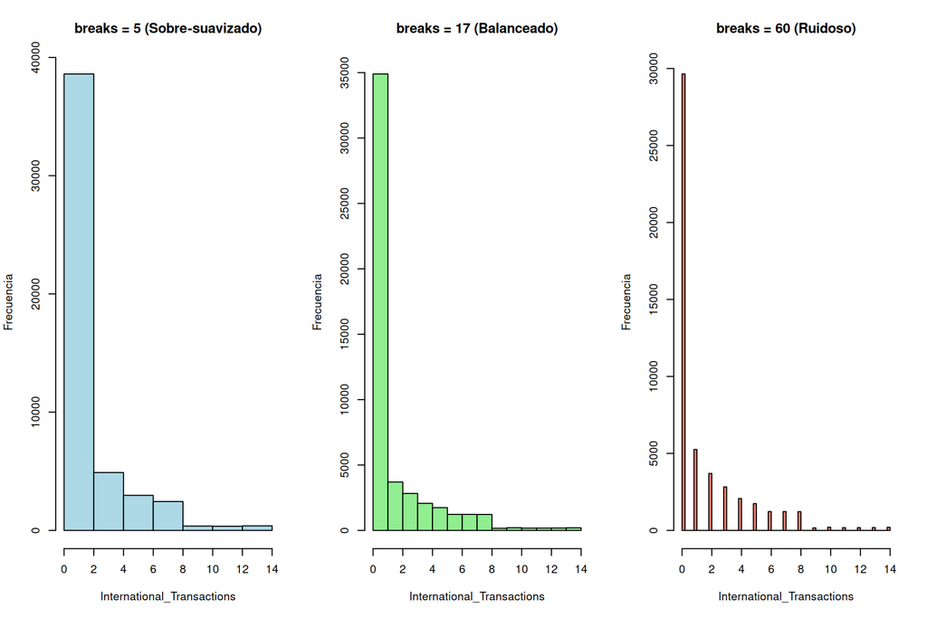

**International_Transactions** mide el número de compras hechas en el exterior. La mayoría de clientes no compra en el exterior, así que el valor típico es cero y las pocas decenas de compras internacionales aparecen como cola derecha discreta. Por eso la versión con `breaks = 5` aplana la forma y esconde el detalle, la de `breaks = 60` la fragmenta en picos que son ruido muestral, y la de Sturges es la que la muestra sin deformarla.

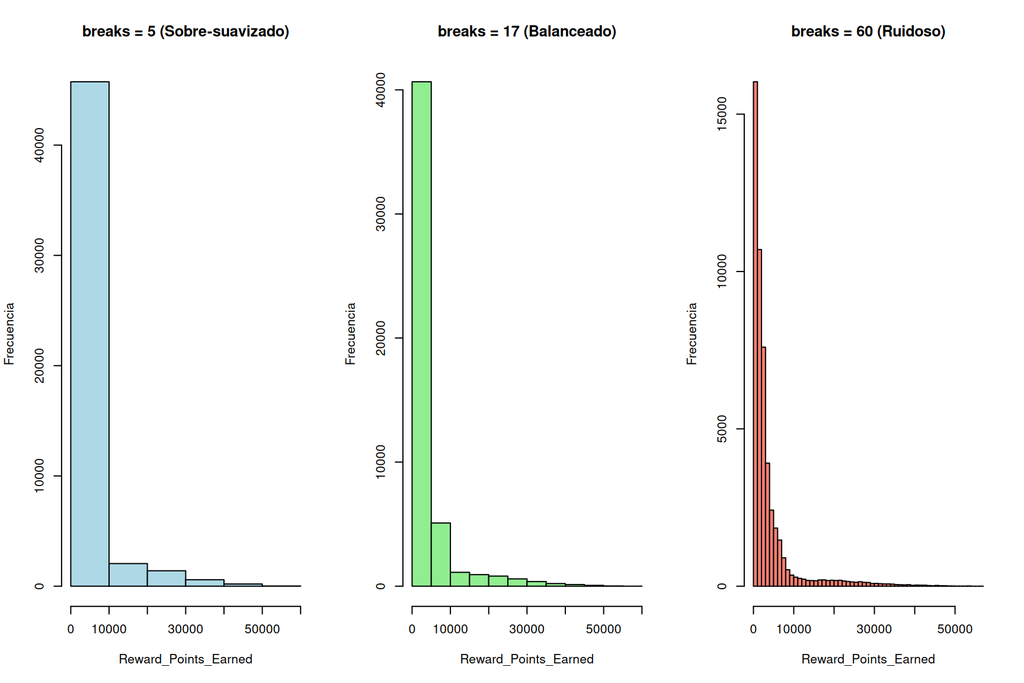

**Reward_Points_Earned** mide los puntos de recompensa acumulados, que el banco calcula a partir del gasto. Los puntos se calculan como función del gasto, así que la gráfica es esencialmente la del gasto mensual reescalada: mismo pico bajo y misma cola derecha. Por eso la versión con `breaks = 5` aplana la forma y esconde el detalle, la de `breaks = 60` la fragmenta en picos que son ruido muestral, y la de Sturges es la que la muestra sin deformarla.

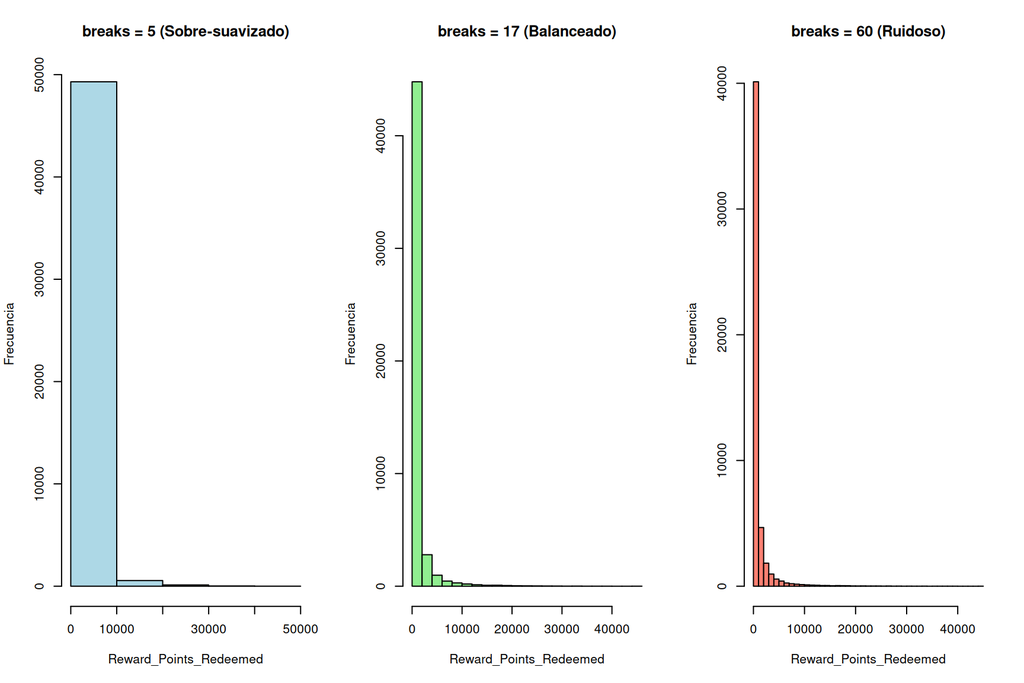

**Reward_Points_Redeemed** mide los puntos de recompensa que el cliente ya redimió. Muchos clientes acumulan puntos pero no los redimen, por eso hay una acumulación en cero y una cola derecha correspondiente a quienes sí los usan, normalmente en redenciones grandes y puntuales. Por eso la versión con `breaks = 5` aplana la forma y esconde el detalle, la de `breaks = 60` la fragmenta en picos que son ruido muestral, y la de Sturges es la que la muestra sin deformarla.

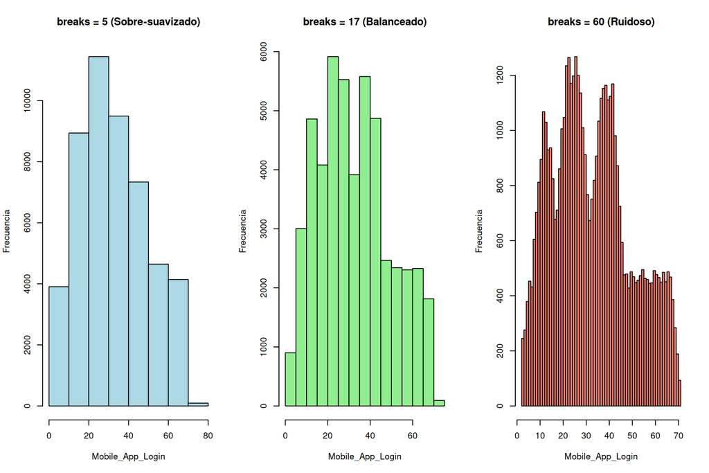

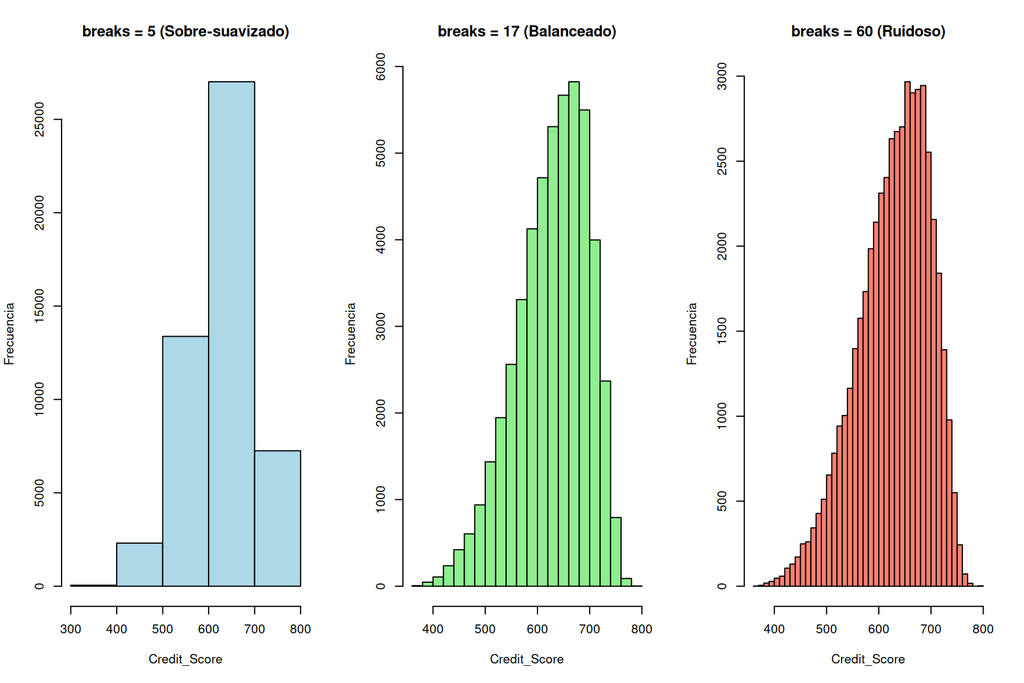

**Credit_Score** mide el puntaje crediticio asignado al cliente. El puntaje está acotado por diseño en un rango estrecho y la mayoría de clientes cae en la zona media-alta; la cola corta hacia la izquierda corresponde a la minoría de perfiles de alto riesgo. Por eso la versión con `breaks = 5` aplana la forma y esconde el detalle, la de `breaks = 60` la fragmenta en picos que son ruido muestral, y la de Sturges es la que la muestra sin deformarla.

## 4.4 Regla de Sturges

La regla de Sturges propone el número óptimo de intervalos para muestras bajo supuestos de normalidad:
$$k =
1 + \log_2(n) = 1 + 3.322 \cdot \log_{10}(n)$$

```r
n_obs <- length(score)
k_sturges <- nclass.Sturges(score)
k_teorico <- 1 + log2(n_obs)

c(n = n_obs, k_Sturges = k_sturges, k_Formula = round(k_teorico, 2))
```

```
#>         n k_Sturges k_Formula
#>  50000.00     17.00     16.61
```

# 5 Módulo 4: Caja y Bigotes (Boxplots) y Detección Univariada de Atípicos (S03)

## 5.1 Los cinco números de Tukey (`fivenum`)

Analizamos el gasto mensual (`Monthly_Spending`):

```r
gasto <- credit$Monthly_Spending
f_gasto <- fivenum(gasto)
names(f_gasto) <- c("Mínimo", "Q1", "Mediana", "Q3", "Máximo")
f_gasto
```

```
#>    Mínimo        Q1   Mediana        Q3    Máximo
#>   2235.63  26646.33  50022.38  83032.36 691687.96
```

```r
ingreso <- credit$Annual_Income
f_ingreso <- fivenum(ingreso)
names(f_ingreso) <- c("Mínimo", "Q1", "Mediana", "Q3", "Máximo")
f_ingreso
```

```
#>    Mínimo        Q1   Mediana        Q3    Máximo
#>  100050.0  657770.5 1127629.5 1663677.0 7995831.0
```

## 5.2 Rango Intercuartílico ($RIC$) y Límites de Tukey

El criterio de Tukey define las barreras para valores atípicos (*outliers*) como:
$$\text{Límite
Inferior} = Q_1 - 1.5 \cdot RIC$$
$$\text{Límite Superior} = Q_3 + 1.5 \cdot
RIC$$

```r
q1_gasto <- f_gasto["Q1"]
q3_gasto <- f_gasto["Q3"]
ric_gasto <- q3_gasto - q1_gasto

lim_inf_gasto <- q1_gasto - 1.5 * ric_gasto
lim_sup_gasto <- q3_gasto + 1.5 * ric_gasto

c(Q1 = q1_gasto, Q3 = q3_gasto, RIC = ric_gasto,
  Lim_Inferior = lim_inf_gasto, Lim_Superior = lim_sup_gasto)
```

```
#>           Q1.Q1           Q3.Q3          RIC.Q3 Lim_Inferior.Q1 Lim_Superior.Q3
#>        26646.33        83032.36        56386.03       -57932.71       167611.40
```

## 5.3 Conteo de atípicos univariados

```r
atipicos_gasto <- gasto[gasto < lim_inf_gasto | gasto > lim_sup_gasto]
n_atipicos_gasto <- length(atipicos_gasto)
pct_atipicos_gasto <- (n_atipicos_gasto / length(gasto)) * 100

c(N_Atipicos = n_atipicos_gasto, Porcentaje = round(pct_atipicos_gasto, 3))
```

```
#> N_Atipicos Porcentaje
#>   4213.000      8.426
```

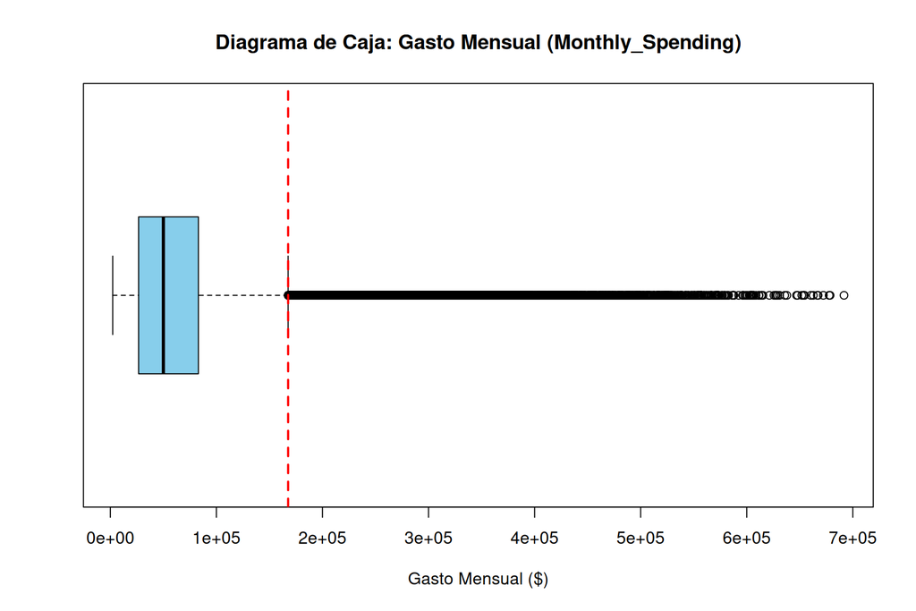

```r
boxplot(gasto, horizontal = TRUE, col = "skyblue",
        main = "Diagrama de Caja: Gasto Mensual (Monthly_Spending)",
        xlab = "Gasto Mensual ($)")
abline(v = c(lim_inf_gasto, lim_sup_gasto), col = "red", lty = 2, lwd = 2)
```

```
--------------------------------------------------
Análisis para la variable:  Age
--------------------------------------------------
          Q1.Q1           Q3.Q3          RIC.Q3 Lim_Inferior.Q1 Lim_Superior.Q3
           27.0            44.0            17.0             1.5            69.5
Conteo de atípicos univariados:
N_Atipicos Porcentaje
   278.000      0.556
```

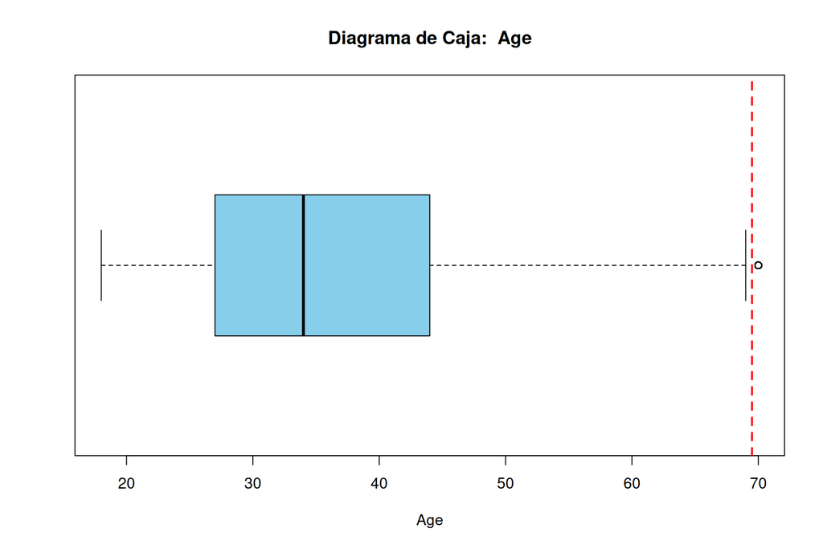

````r
numeric_cols <- names(credit)[sapply(credit, is.numeric)]

for (col_name in numeric_cols) {
  current_var <- credit[[col_name]]

  # Calculate Tukey's five-number summary
  f_var <- fivenum(current_var)
  names(f_var) <- c("Mínimo", "Q1", "Mediana", "Q3", "Máximo")

  q1_var <- f_var["Q1"]
  q3_var <- f_var["Q3"]
  ric_var <- q3_var - q1_var

  lim_inf_var <- q1_var - 1.5 * ric_var
  lim_sup_var <- q3_var + 1.5 * ric_var

  # Salida de consola dentro de un bloque de código
  cat("\n\n```\n")
  cat("--------------------------------------------------\n")
  cat("Análisis para la variable: ", col_name, "\n")
  cat("--------------------------------------------------\n")

  # Print Tukey's statistics
  print(c(Q1 = q1_var, Q3 = q3_var, RIC = ric_var,
          Lim_Inferior = lim_inf_var, Lim_Superior = lim_sup_var))

  # Count univariate outliers
  atipicos_var <- current_var[current_var < lim_inf_var | current_var > lim_sup_var]
  n_atipicos_var <- length(atipicos_var)
  pct_atipicos_var <- (n_atipicos_var / length(current_var)) * 100

  cat("Conteo de atípicos univariados:\n")
  print(c(N_Atipicos = n_atipicos_var, Porcentaje = round(pct_atipicos_var, 3)))
  cat("```\n\n")

  # Generate boxplot
  boxplot(current_var, horizontal = TRUE, col = "skyblue",
          main = paste("Diagrama de Caja: ", col_name),
          xlab = col_name)
  abline(v = c(lim_inf_var, lim_sup_var), col = "red", lty = 2, lwd = 2)

  # Análisis corto de la variable y de lo que muestra su boxplot
  cat(parrafo(col_name, "box"))
}
````

**Age** mide la edad del titular en años. La forma es casi simétrica con una leve inclinación hacia la derecha: la cartera se concentra entre los 27 y los 44 años y se adelgaza hacia los 70, porque hay pocos titulares mayores y ninguno menor de 18. La regla de Tukey deja 278 datos fuera de los bigotes (0.56%), todos en la cola derecha; no son errores de captura sino la parte extrema de esa misma cola.

```
--------------------------------------------------
Análisis para la variable:  Annual_Income
--------------------------------------------------
          Q1.Q1           Q3.Q3          RIC.Q3 Lim_Inferior.Q1 Lim_Superior.Q3
       657770.5       1663677.0       1005906.5       -851089.2       3172536.8
Conteo de atípicos univariados:
N_Atipicos Porcentaje
  4037.000      8.074
```

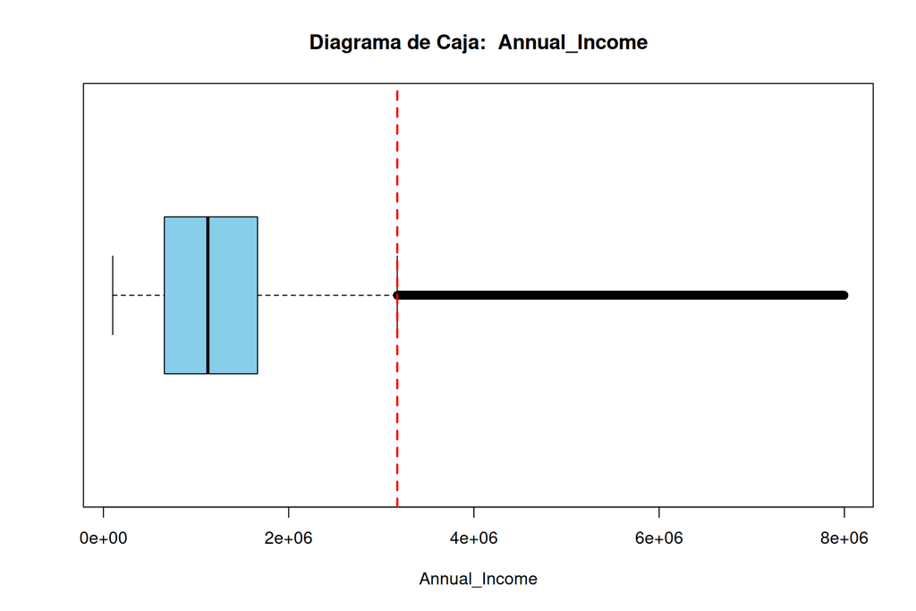

**Annual_Income** mide el ingreso anual declarado por el cliente. La cola larga hacia la derecha es lo esperable en cualquier variable de ingreso: la mayoría gana alrededor de la mediana y unos pocos ganan varias veces más, lo que empuja la media muy por encima de la mediana. La regla de Tukey deja 4.037 datos fuera de los bigotes (8.07%), todos en la cola derecha; no son errores de captura sino la parte extrema de esa misma cola.